# sklearn.datasets.load_digits

**sklearn.datasets.load_digits(*, *n_class=10*, *return_X_y=False*, *as_frame=False*)[[source]](https://github.com/scikit-learn/scikit-learn/blob/f3f51f9b6/sklearn/datasets/_base.py#L821)**

Load and return the digits dataset (classification).

Each datapoint is a 8x8 image of a digit.

| Classes | 10 |
| --- | --- |
| Samples per class | ~180 |
| Samples total | 1797 |
| Dimensionality | 64 |
| Features | integers 0-16 |

This is a copy of the test set of the UCI ML hand-written digits datasets https://archive.ics.uci.edu/ml/datasets/Optical+Recognition+of+Handwritten+Digits

Read more in the [User Guide](https://scikit-learn.org/1.1/datasets/toy_dataset.html#digits-dataset).

**Parameters:**

**n_class**int, default=10**

The number of classes to return. Between 0 and 10.

**return_X_y**bool, default=False**

If True, returns `(data, target)` instead of a Bunch object. See below for more information about the `data` and `target` object.

New in version 0.18.

**as_frame**bool, default=False**

If True, the data is a pandas DataFrame including columns with appropriate dtypes (numeric). The target is a pandas DataFrame or Series depending on the number of target columns. If `return_X_y` is True, then (`data`, `target`) will be pandas DataFrames or Series as described below.

New in version 0.23.

**Returns:**

**data**`Bunch`**

Dictionary-like object, with the following attributes.

**data{ndarray, dataframe} of shape (1797, 64)**

The flattened data matrix. If `as_frame=True`, `data` will be a pandas DataFrame.

**target: {ndarray, Series} of shape (1797,)**

The classification target. If `as_frame=True`, `target` will be a pandas Series.

**feature_names: list**

The names of the dataset columns.

**target_names: list**

The names of target classes.

New in version 0.20.

**frame: DataFrame of shape (1797, 65)**

Only present when `as_frame=True`. DataFrame with `data` and `target`.

New in version 0.23.

**images: {ndarray} of shape (1797, 8, 8)**

The raw image data.

**DESCR: str**

The full description of the dataset.

**(data, target)**tuple if `return_X_y` is True**

A tuple of two ndarrays by default. The first contains a 2D ndarray of shape (1797, 64) with each row representing one sample and each column representing the features. The second ndarray of shape (1797) contains the target samples. If `as_frame=True`, both arrays are pandas objects, i.e. `X` a dataframe and `y` a series.

New in version 0.18.

#### Examples

To load the data and visualize the images:

```
>>> from sklearn.datasets import load_digits
>>> digits = load_digits()
>>> print(digits.data.shape)
(1797, 64)
>>> import matplotlib.pyplot as plt
>>> plt.gray()
>>> plt.matshow(digits.images[0])
<...>
>>> plt.show()
```

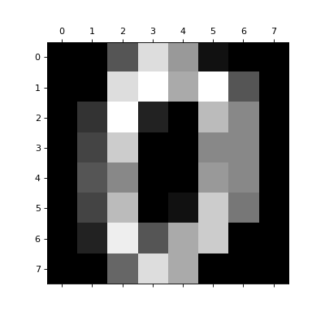

## Examples using `sklearn.datasets.load_digits`

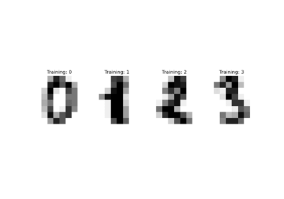

Recognizing hand-written digits

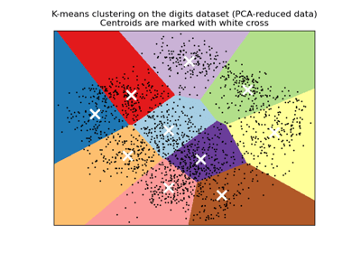

A demo of K-Means clustering on the handwritten digits data

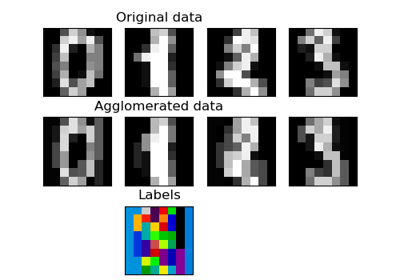

Feature agglomeration

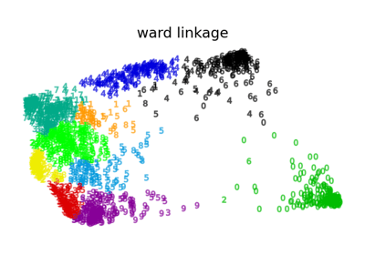

Various Agglomerative Clustering on a 2D embedding of digits

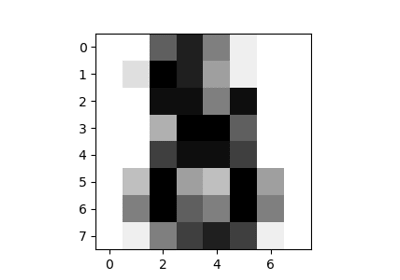

The Digit Dataset

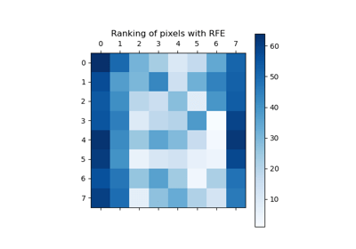

Recursive feature elimination

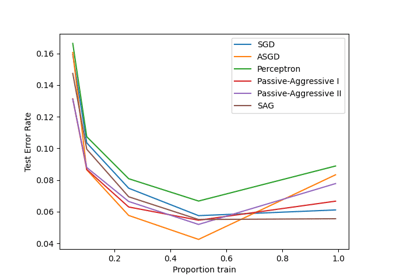

Comparing various online solvers

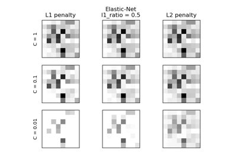

L1 Penalty and Sparsity in Logistic Regression

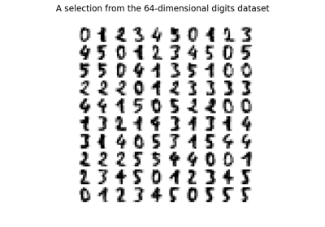

Manifold learning on handwritten digits: Locally Linear Embedding, Isomap…

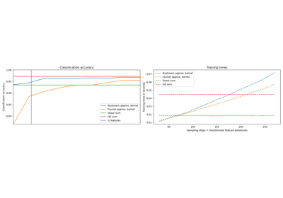

Explicit feature map approximation for RBF kernels

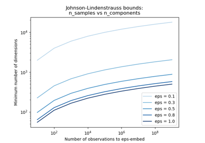

The Johnson-Lindenstrauss bound for embedding with random projections

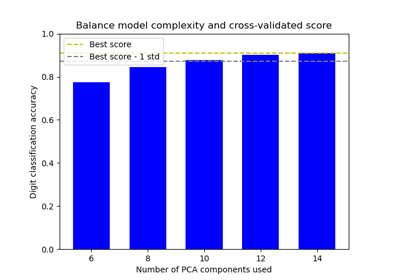

Balance model complexity and cross-validated score

Comparing randomized search and grid search for hyperparameter estimation

Custom refit strategy of a grid search with cross-validation

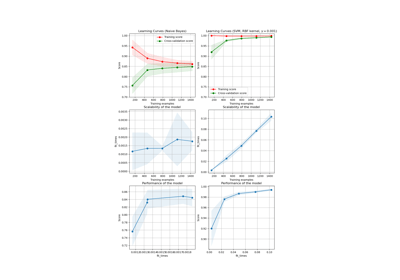

Plotting Learning Curves

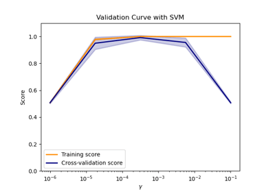

Plotting Validation Curves

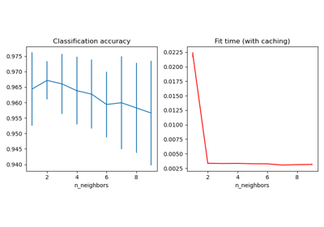

Caching nearest neighbors

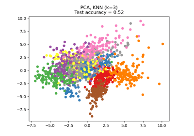

Dimensionality Reduction with Neighborhood Components Analysis

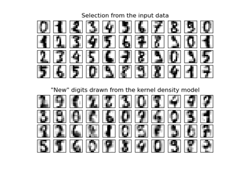

Kernel Density Estimation

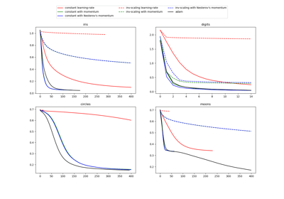

Compare Stochastic learning strategies for MLPClassifier

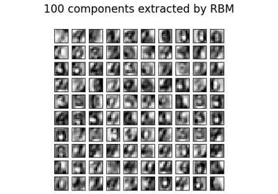

Restricted Boltzmann Machine features for digit classification

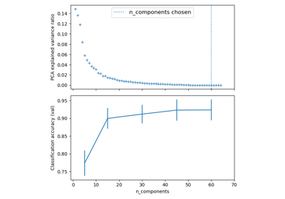

Pipelining: chaining a PCA and a logistic regression

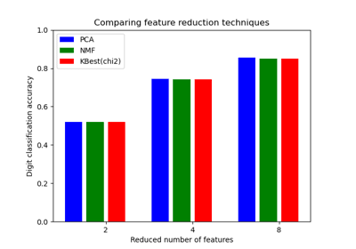

Selecting dimensionality reduction with Pipeline and GridSearchCV

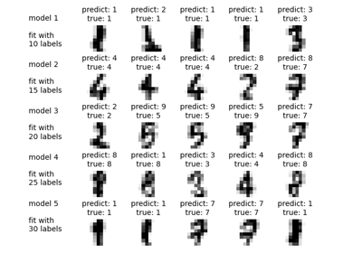

Label Propagation digits active learning

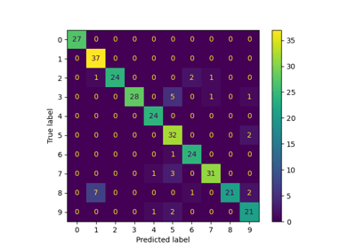

Label Propagation digits: Demonstrating performance

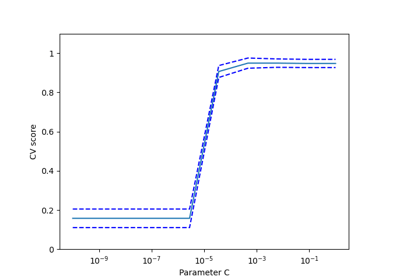

Cross-validation on Digits Dataset Exercise

Digits Classification Exercise